# A Espiral do Clima — Anomalias da Tempratura Global nos Úllimos 145 Anos

# Introdução

As mudanças climáticas são um fenômeno global muitas vezes cercado de ceticismo e de difícil percepção a curto prazo. Por isso, muitas vezes essa progressão é difícil de ser compreendida por meio de gráficos de séries temporais tradicionais, visto que os mesmos revelam apenas um resultado final estático. Dessa forma, é necessário dar um passo a mais na visualização de dados, alcançando um nível que possibilite um entendimento gradual do problema.

Um das formas mais eficientes de comunicar um problema progressivo é por meio de animações que exploram não só a informação que os dados tem a oferecer, mas também a evolução ao longo do tempo, e é aí que entra a *Espiral Climática*. Desenvolvida originalmente por Ed Hawkins, ela nos permite observar claramente como o aumento gradual das temperaturas vem se desenvolvendo há mais de um século.

Neste dashboard, é apresentada uma animação que mostra uma progressão mensal e anualmente cíclica das *anomalias de temperatura média global* de 1880-2025, construída a partir de dados históricos e disponibilizados publicamente pela NASA (National Aeronautics and Space Administration).

# Como é medida a temperatura global

Primeiramente, é crucial entender o que são anomalias de temperatura e por que ela são tão importantes.  
Elas são chamadas assim porque representam um desvio em relação a uma média de base tomada como referência, que nesse caso é a temperatura média global dos anos 1951-1980. As anomalias nos dão informações muito mais valiosas do que apenas medir os valores absolutos de temperatura, pois além de nos dar um ponto de comparação, também é uma medida imparcial, visto que as temperaturas não são as mesmas em todo o mundo. Se tomarmos como exemplo a Antártida, temos temperaturas que beiram os -100°C, enquanto também há desertos que ultrapassam facilmente o marco dos 50°C. Portanto, é necessário uma referência para podermos avaliar corretamente a progressão do aquecimento global.

Os anos 1951-1980 são utilizados como base pois são um período anterior ao aumento excessivo de temperatura, que viria nas década seguintes. Nessa época, foram realizadas medidas muito precisas em todo o mundo, o que diminui drasticamente as chances de erro e, além disso, nessa época o mundo estava em um nível agradável de temperatura, o que poderia ser chamado de ideal, portanto serve perfeitamente como ponto de referência.

# A Espiral Climática

A animação em questão foi inspirada em uma animação desenvolvida pelo Scientific Visualization Studio, da NASA, originalmente proposta por Ed Hawkins, cientista da Universidade de Reading, no Reino Unido. Ao unir um século e meio de dados climáticos, o gráfico animado nos dá uma representação dinâmica e progressiva das mudanças climáticas no mundo como um todo.

# Visualização animada

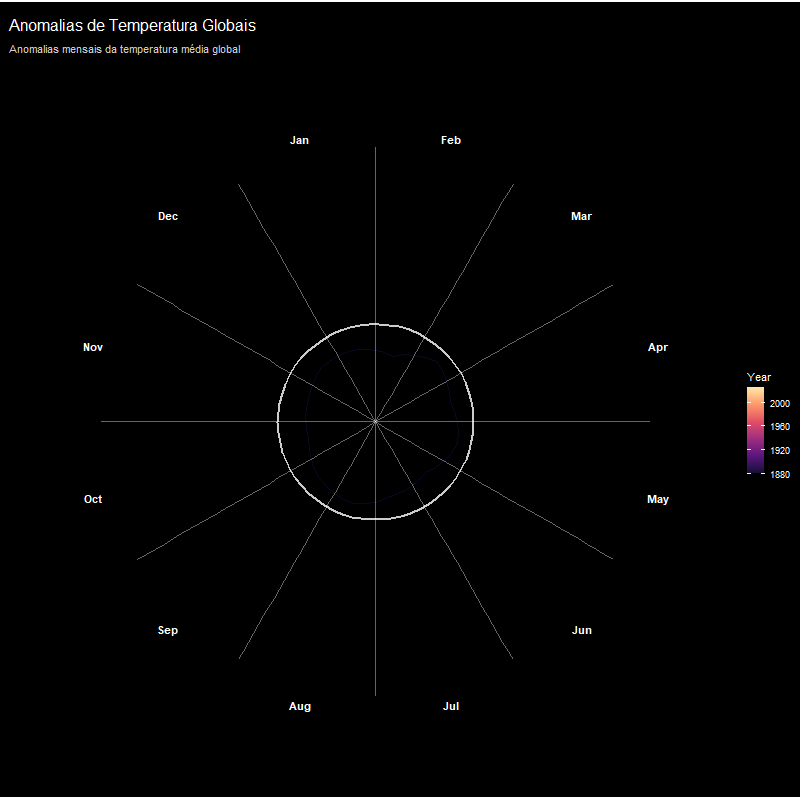

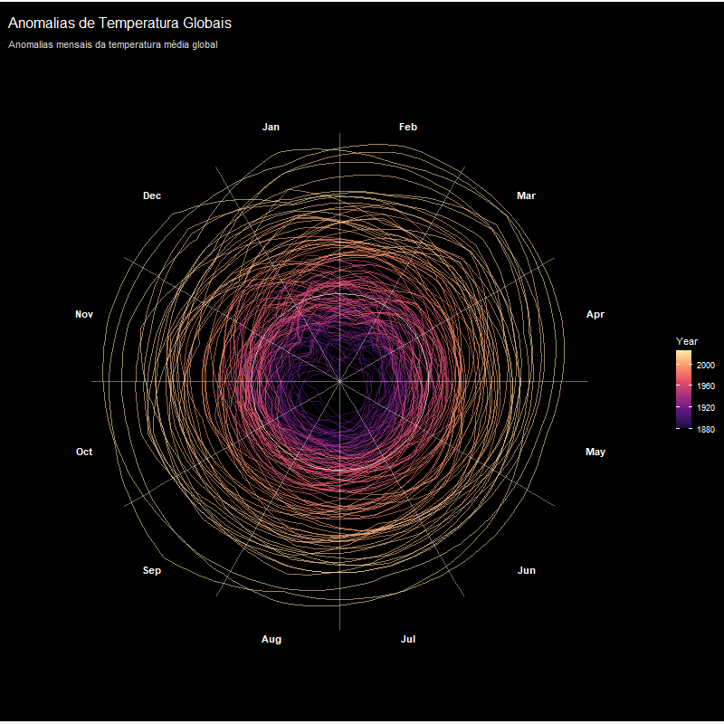

# O que a animação nos diz

Ao fim do século XIX e início do XX, vemos que as temperaturas ficam próximas e até dentro do círculo, o que mostra que estavam mais baixas ou parecidas com a base de comparação O resultado muda logo no fim do século XX, onde as linhas começam a se distanciar cada vez mais rapidamente, e assim que alcançamos os anos 2000 elas praticamente saltam para o limite da espiral, o que mostra o aumento exponencial das anomalias.

Isso tudo confirma o que já é de conhecimento geral no mundo científico: o aquecimento global proride de forma não-linear. Por mais que a emissão de gases possa se manter constante ao longo do tempo, o acúmulo destes é cada vez maior, o que faz com que cada vez mais as temperaturas aumentem mais rapidamente, trazendo consequências gigantes para o mundo todo, como catástrofes naturais intensificadas, chuvas mais fortes, derretimento de geleiras, verões muito mais quentes e invernos menos frios, entre outros.

# Conclusão

Com isso, fica clara a rápida progressão das anomalias de temperatura globais, principalmente desde o fim do século XX. Além disso, vimos que uma visualização animada nos dá muito mais informações do que um gráfico estático, principalmente em se tratando de séries temporais.

Por fim, a construção dessa animação, especialmente sua idealização por ed Hawkins, mostra a importância de sempre buscarmos formas mais criativas de fazer uma boa visualização de dados, em especial quando temos dados que se alteram ao longo do tempo e precisamos ver detalhes que um gráfico comum não nos permitiria enxergar.